# Lecture 14- Binomial Regression

Peter Shaffery

3/2/2021

# Introduction

## Example: Titanic dataset

```r
library(tidyverse)
library(magrittr)

dat = read.csv('../../data/titanic.csv')

# the titanic data contains some missing data that we'll just ignore for now....
dat %<>% drop_na

# we don't care about a few of the columns
dat %<>% select(-c('name','ticket','cabin'))

dat %>% head
```

```
##   survived pclass    sex     age sibsp parch     fare embarked
## 1        1      1 female 29.0000     0     0 211.3375        S
## 2        1      1   male  0.9167     1     2 151.5500        S
## 3        0      1 female  2.0000     1     2 151.5500        S
## 4        0      1   male 30.0000     1     2 151.5500        S
## 5        0      1 female 25.0000     1     2 151.5500        S
## 6        1      1   male 48.0000     0     0  26.5500        S
```

```r
dat$pclass %<>% as.factor
```

| Variable | Def’n |
| --- | --- |
| `survived` | Whether the passenger survived (1) or not (0) |
| `pclass` | Passenger’s ticket class (1 is “first class”, etc.) |
| `sex` | Passenger’s sex |
| `age` | Passenger’s age |
| `sibsp` | Number of siblings and spouses aboard |
| `parch` | Number of parents and children aboard |
| `fare` | Price paid for ticket |
| `embarked` | Port passenger boarded ship (C = Cherbourg, Q = Queenstown, S = Southampton) |

What characteristics predict if someone survived or not?

## Logistic Regression

One way we could start to answer this question is by modeling the survival outcome with a *Bernoulli distribution*. That is, we assume that for an individual passenger their survival $y_i$ is a random random variabl, with a probability $\pi_i$ that $y_i=1$ (and conversely a probability $(1-\pi_i)$ that $y_i=0$). For a given passenger the PMF of this model is:

$$y_i \sim \text{Bernoulli}(\pi_i) = \pi_i^{y_i} (1-\pi_i)^{(1-y_i)}$$

Recall that the Bernoulli distribution is a special case of the Binomial distribution:

$$y_i \sim \text{Binomial}(\pi_i) = {n_i \choose y_i } \pi_i^{y_i} (1-\pi_i)^{(n_i-y_i)}$$
Where $n_i=1$.

The expected value of the Bernoulli distribution is:
$$E[y_i] = \pi_i$$

And thus we can make it a GLM using a model for $\pi_i$:

$$g(\pi_i) = \vec{x_i}^T\vec{\beta}$$

### A Weird Choice for $g$

One choice for $g$ that sees some usage (for some reason), is a *linear probability model*, $\pi_i= \vec{x_i}^T\vec{\beta}$.

This model has a few problems, but mainly we can get an estimate $\hat{\pi}_i$ which is less than 0 or greater than 1, so that’s out.

A slightly more reasonable choice for $g$ would be model which is linear inside $[0,1]$, but constant otherwise. Something like:

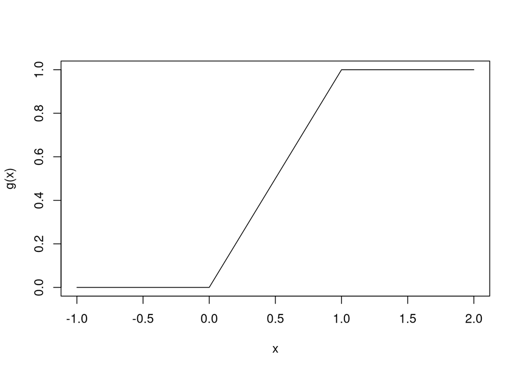

This type of model sees some usage in dose-response modeling (see IGLM 7.3)

### A Nicer Choice for $g$

Rather than trying to model $\pi_i$ directly, we might observe that the *natural parameter* for the Binomial distribution is a much easier candidate to model:
$$b(\pi_i) = \log{\left( \frac{\pi_i}{1-\pi_i} \right)}$$
Certainly this quantity can be positive or negative, which was the primary difficulty we had modeling $\pi$ directly.

Hence a common choice of linke function is simply:
$$g(\pi_i) = b(\pi_i) = \log{\left( \frac{\pi_i}{1-\pi_i} \right)}$$

This function is named the **logit** function, $g(z) = \log{\left( \frac{z}{1-z} \right)} = \text{logit}(z)$.

Combined, the choice of Bernoulli (or Binomial) distribution and logit link function is known as **logistic regression**. Often this model is expressed in terms of the *inverse* logit, or **logistic** function:

$$\pi_i = \text{logistic}(\vec{x}_i^T \vec{\beta}) = \frac{\exp{(\vec{x}_i^T \vec{\beta})} }{1+\exp{(\vec{x}_i^T \vec{\beta})}}$$
**Take a minute and write down the log-likelihood for this choice of distribution and link function**

Writing.

Writing..

Writing…

For a single datapoint we said that $y_i \sim \pi_i^{y_i} (1-\pi)^{1-y_i}$, hence the log-likelihood for the entire dataset (in terms of $\pi_i$) is:

$$l(\pi_i) = \sum_i y_i \log\pi_i + (1-y_i) \log(1-\pi_i)$$

Now, subbing in $\pi_i = \frac{\exp{(\vec{x}_i^T \vec{\beta})} }{1+\exp{(\vec{x}_i^T \vec{\beta})}}$ gives us:

$$l(\vec{\beta}) = \sum_i y_i \log{\left(\frac{\exp{(\vec{x}_i^T \vec{\beta})} }{1+\exp{(\vec{x}_i^T \vec{\beta})}} \right)} + (1-y_i) \log{\left( \frac{1}{1+\exp{(\vec{x}_i^T \vec{\beta})}} \right)}$$

Which can be simplified to:
$$l(\vec{\beta}) = \sum_i y_i (\vec{x}_i^T \vec{\beta} ) - \log{(1+\exp{(\vec{x}_i^T \vec{\beta})})}$$
### Interpreting Logistic Regression

Say that we have a simple model with only one variable $x_i$:
$$\log{\left( \frac{\pi_i}{1-\pi_i} \right)} = \beta_0 + \beta_1 x_i$$
How do we interpet the effect of increasing $x_i$ by 1 unit?

The typical way of interpreting the coefficient $\beta_1$ is through the **odds ratio**. If we imagine one individual (say a passenger in the Titanic dataset) with variable value $x$, and another with variable $x+1$, then the odds ratio is defined:

$$\begin{split}
\text{OR} &= \frac{ \text{odds}(x+1) }{\text{odds}(x)} \\
&= \frac{\pi(x+1)/(1-\pi(x+1))}{ \pi(x)/(1-\pi(x))}\\
&= \frac{\exp{(\beta_0 + \beta_1(x+1))}}{\exp{(\beta_0 + \beta_1 x)}}\\
&= \exp \beta_1\\
\end{split}$$
For a model with multiple variables:
$$\log{\frac{\pi_i}{1-\pi_i}} = \beta_0 + \beta_1 x_{1i} + ... + \beta_m x_{mi}$$
We could define multiple such odds ratios:
$$OR_m = \exp{\beta_m}$$

## Example: Titanic (con’t)

Let’s run a simple model on `pclass`, `age`:

```r
mod = glm(survived ~ pclass+age, family=binomial, data=dat)
summary(mod)
```

```
##
## Call:
## glm(formula = survived ~ pclass + age, family = binomial, data = dat)
##
## Deviance Residuals:
##     Min       1Q   Median       3Q      Max
## -2.0576  -0.8986  -0.6673   1.0643   2.2744
##
## Coefficients:
##              Estimate Std. Error z value Pr(>|z|)
## (Intercept)  2.063195   0.260073   7.933 2.14e-15 ***
## pclass2     -1.217554   0.193512  -6.292 3.14e-10 ***
## pclass3     -2.220469   0.193816 -11.457  < 2e-16 ***
## age         -0.037317   0.005515  -6.766 1.32e-11 ***
## ---
## Signif. codes:  0 '***' 0.001 '**' 0.01 '*' 0.05 '.' 0.1 ' ' 1
##
## (Dispersion parameter for binomial family taken to be 1)
##
##     Null deviance: 1413.6  on 1044  degrees of freedom
## Residual deviance: 1255.5  on 1041  degrees of freedom
## AIC: 1263.5
##
## Number of Fisher Scoring iterations: 4
```

```r
print('Odds ratios:')
```

```
## [1] "Odds ratios:"
```

```r
print(exp(mod$coefficients))
```

```
## (Intercept)     pclass2     pclass3         age
##   7.8710754   0.2959531   0.1085582   0.9633712
```

**Note that these ORs are not probabilities**. Only the `(Intercept)` OR can be interpreted as “true odds”, since it gives you the odds of “success” (or survival) for the "base class* in our model. The OR corresponding to any variable *modifies* the odds.

Hence for a younger passenger in first class the survival odds were just under 8 to 1. For the same passenger in second class those odds were reduced to $.29 * 7.87 \approx 2.3$, so about 2 to 1. The same passenger in third class had survival odds $.1*7.87 \approx .79$ so roughly 4 to 3 *against*. Every additional year on a passenger’s age knocked ~4% off their survival odds.

# Binomially Distributed Data

In the above example, it was easy to think about each passenger as an individual *Bernoulli trial*, and so assuming $n_i=1$ was a natural choice.

In many cases, however, logistic regression is applied to Binomial data with $n_i > 1$

In general, logistic regression doesn’t care whether our data has $n_i=1$ or not, but it’s instructive to look at an example. Let’s see a case from dose-response modeling (IGLM 7.3.1).

Say that we are trying to determine the properties of carbon disulphide, a gaseous insectiside, on a certain species of beetle. The following data shows the number of beetles dead after five hours of exposure:

```r
dose.dat = read.csv('../../data/beetles.csv')
dose.dat
```

```
##   dose  n  y
## 1 1.69 59  6
## 2 1.72 60 13
## 3 1.76 62 18
## 4 1.78 56 28
## 5 1.81 63 52
## 6 1.84 59 53
## 7 1.86 62 61
## 8 1.88 60 60
```

From the Binomial PMF, we can quickly see that the likelihood function for this data (in terms of $\pi_i$) is:
$$l(\pi_i;n_i) = \sum_i y_i \log\pi_i + (n_i-y_i) \log(1-\pi_i) + \log{{n_i \choose y_i}}$$
Note that the last term ${n_i \choose y_i}$ does not depend on $\pi_i$ and hence will not depend on $\vec{\beta}$, so the only part we care about is:
$$\sum_i y_i \log\pi_i + (n_i-y_i) \log(1-\pi_i)$$
Now say that instead of a Binomial distribution we had instead treated each beetle’s outcome $z_j$ as a Bernoulli trial:
$$\sum_j z_j \log\pi_j + (1-z_j) \log(1-\pi_j)$$
Since we can group the $n_i$ individuals at each dose level, $x_j = x_i$:
$$\begin{split}
&\sum_i \left(\sum_{j=1}^{n_i} z_j\right) \log\pi_i + \left(\sum_{j=1}^{n_i} 1-z_j \right) \log(1-\pi_i) \\
&= \sum_i y_i \log\pi_i + (n_i - y_i) \log(1-\pi_i) \\
\end{split}$$
So when we take the derivative and compute the score function we will get the same thing, regardless of how we modeled.

Unfortunately, `glm` has a **ludicrous** usage pattern for fitting this kind of “grouped” binomial data (ie. data where $n_i>1$). You need to construct a matrix with two columns, where the first contains the $y_i$ (number of successes), while the second contains $n_i-y_i$ (the number of failures). This looks like:

```r
dose.dat$fails = dose.dat$n - dose.dat$y
lhs = as.matrix(dose.dat[,c('y','fails')])

mod.logit = glm(lhs~dose.dat$dose, family=binomial)
summary(mod.logit)
```

```
##
## Call:
## glm(formula = lhs ~ dose.dat$dose, family = binomial)
##
## Deviance Residuals:
##     Min       1Q   Median       3Q      Max
## -1.8986  -0.5475   0.9842   1.3315   1.7179
##
## Coefficients:
##               Estimate Std. Error z value Pr(>|z|)
## (Intercept)    -60.103      5.164  -11.64   <2e-16 ***
## dose.dat$dose   33.934      2.903   11.69   <2e-16 ***
## ---
## Signif. codes:  0 '***' 0.001 '**' 0.01 '*' 0.05 '.' 0.1 ' ' 1
##
## (Dispersion parameter for binomial family taken to be 1)
##
##     Null deviance: 284.202  on 7  degrees of freedom
## Residual deviance:  13.633  on 6  degrees of freedom
## AIC: 43.831
##
## Number of Fisher Scoring iterations: 4
```

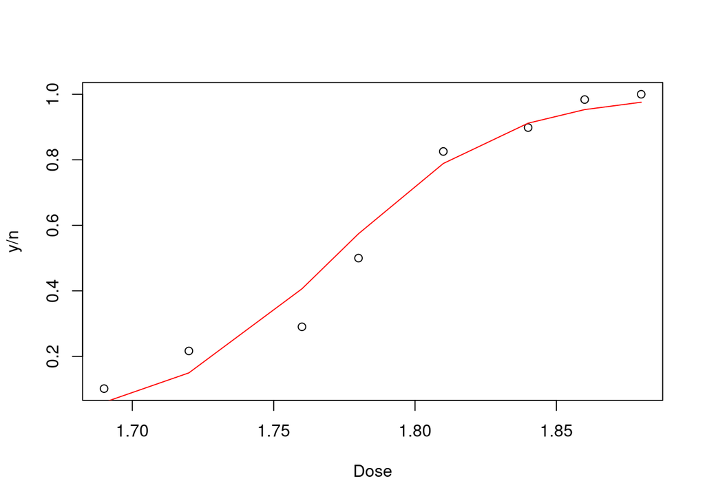

```r
plot(dose.dat$dose,dose.dat$y/dose.dat$n,xlab='Dose',ylab='y/n')
# note the type='response', which is special for GLMS and produces predictions on the $[y_i] scale
lines(dose.dat$dose,predict(mod.logit, type='response'),col='red')
```

```r
print('Odds ratios:')
```

```
## [1] "Odds ratios:"
```

```r
exp(mod.logit$coefficients)
```

```
##   (Intercept) dose.dat$dose
##  7.897278e-27  5.462866e+14
```

# Alternate Link Functions

Let’s look at a few other common link functions. First up is the probit model:

$$\Phi^{-1}(\pi_i) = \vec{x}_i^T \vec{\beta}$$
The function $\Phi$ is the CDF of the standard normal distribution:
$$\begin{split}
X &\sim N(0,1)\\
\Phi(x) &= Pr[X \leq X| \mu=0, \sigma^2=1]
\end{split}$$
Since $\pi_i = \Phi(\vec{x}_i^T \vec{\beta})$ it is guaranteed to stay in $[0,1]$ (since it’s a probability).

In general, the probit and logit functions operate *very* similarly as link functions:

```r
mod.probit = glm(lhs~dose.dat$dose, family=binomial(link='probit'))
summary(mod.probit)
```

```
##
## Call:
## glm(formula = lhs ~ dose.dat$dose, family = binomial(link = "probit"))
##
## Deviance Residuals:
##     Min       1Q   Median       3Q      Max
## -2.1365  -0.5795   0.9642   1.1333   1.4017
##
## Coefficients:
##               Estimate Std. Error z value Pr(>|z|)
## (Intercept)    -34.466      2.608  -13.21   <2e-16 ***
## dose.dat$dose   19.471      1.465   13.29   <2e-16 ***
## ---
## Signif. codes:  0 '***' 0.001 '**' 0.01 '*' 0.05 '.' 0.1 ' ' 1
##
## (Dispersion parameter for binomial family taken to be 1)
##
##     Null deviance: 284.202  on 7  degrees of freedom
## Residual deviance:  12.641  on 6  degrees of freedom
## AIC: 42.84
##
## Number of Fisher Scoring iterations: 4
```

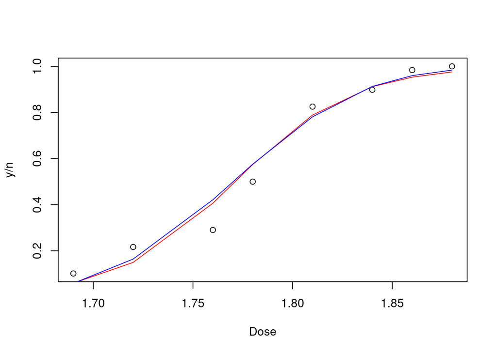

```r
plot(dose.dat$dose,dose.dat$y/dose.dat$n,xlab='Dose',ylab='y/n')
lines(dose.dat$dose,predict(mod.logit, type='response'),col='red')
lines(dose.dat$dose,predict(mod.probit, type='response'),col='blue')
```

Note that even though the coefficients are markedly different, the ultimate predictions are basically the same. Almost always there will be no difference between a logit and a probit model, except a logit model can be interpreted in terms of log-odds and a probit cannot.

Note that, when the coefficient values are set equal, the probit model is slightly steeper:

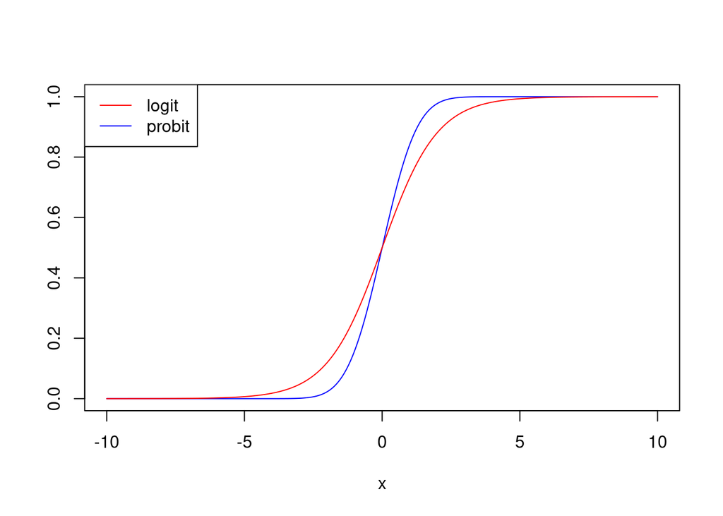

```r
xgrid = seq(-10,10,.01)
logit = exp(xgrid)/(1+exp(xgrid))
probit = pnorm(xgrid)

plot(xgrid,probit,col='blue',type='l',xlab='x',ylab='')
lines(xgrid,logit,col='red')
legend('topleft',col=c('red','blue'),lwd=1,legend=c('logit','probit'))
```

So this might matter to you (but it probably won’t).

Slightly different from logit and probit is the **complementary log-log$ link function:

$$\log{(-\log{(1-\pi_i)} )} = \vec{x}_i^T \vec{\beta}$$
This is referred to in IGLM as the “extreme value model”, as it can be interpreted as the CDF of the extreme value distribution.

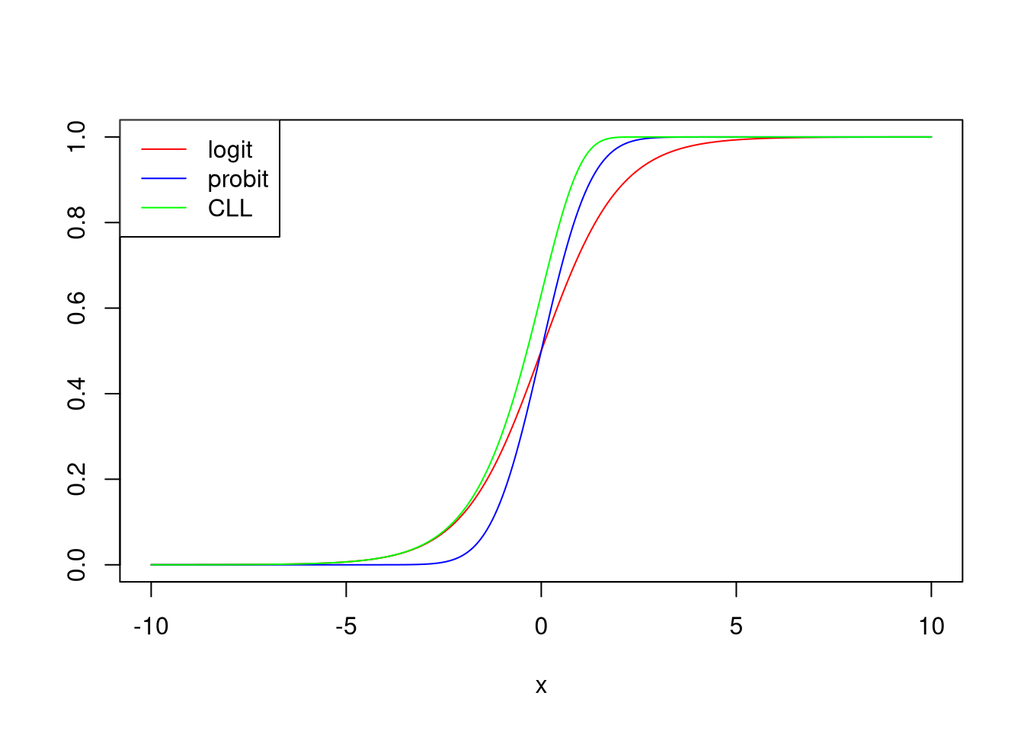

```r
xgrid = seq(-10,10,.01)
cll = 1-exp(-exp(xgrid))

plot(xgrid,logit,col='red',type='l',xlab='x',ylab='')
lines(xgrid,probit,col='blue')
lines(xgrid,cll,col='green')
legend('topleft',col=c('red','blue','green'),lwd=1,legend=c('logit','probit','CLL'))
```

```r
mod.cll = glm(lhs~dose.dat$dose, family=binomial(link='cloglog'))
summary(mod.cll)
```

```
##
## Call:
## glm(formula = lhs ~ dose.dat$dose, family = binomial(link = "cloglog"))
##
## Deviance Residuals:
##      Min        1Q    Median        3Q       Max
## -1.37517  -0.36801   0.07958   0.54314   1.46367
##
## Coefficients:
##               Estimate Std. Error z value Pr(>|z|)
## (Intercept)    -38.889      3.127  -12.44   <2e-16 ***
## dose.dat$dose   21.664      1.736   12.48   <2e-16 ***
## ---
## Signif. codes:  0 '***' 0.001 '**' 0.01 '*' 0.05 '.' 0.1 ' ' 1
##
## (Dispersion parameter for binomial family taken to be 1)
##
##     Null deviance: 284.2024  on 7  degrees of freedom
## Residual deviance:   5.6281  on 6  degrees of freedom
## AIC: 35.826
##
## Number of Fisher Scoring iterations: 4
```

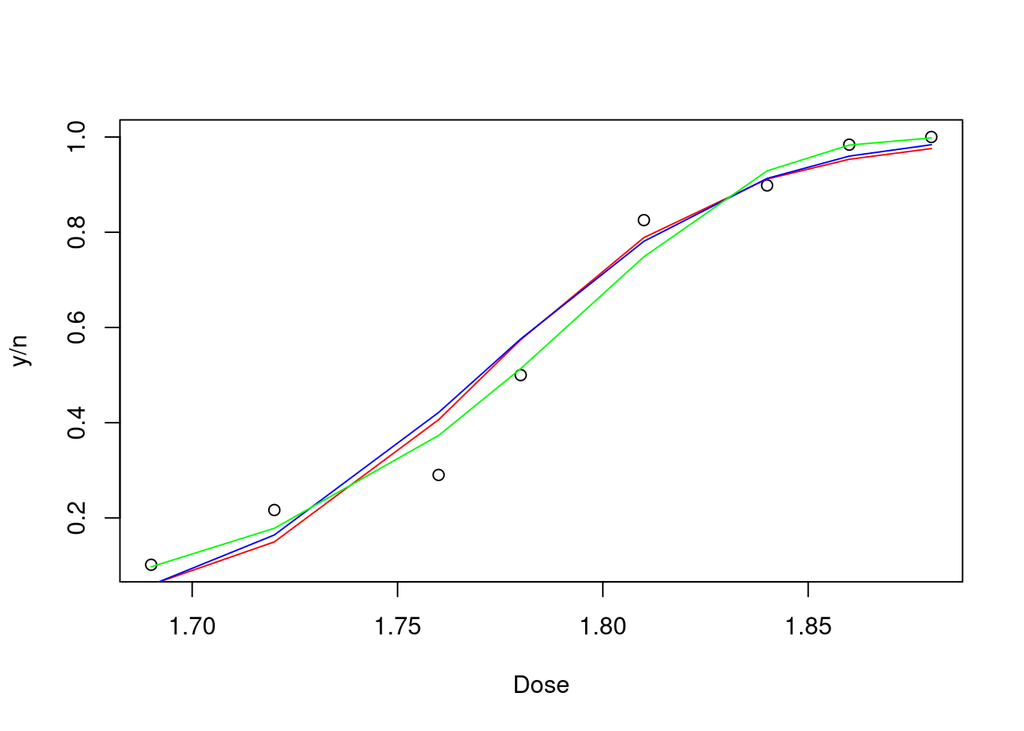

```r
plot(dose.dat$dose,dose.dat$y/dose.dat$n,xlab='Dose',ylab='y/n')
lines(dose.dat$dose,predict(mod.logit, type='response'),col='red')
lines(dose.dat$dose,predict(mod.probit, type='response'),col='blue')
lines(dose.dat$dose,predict(mod.cll, type='response'),col='green')
```

# Model Assessment: Pseudo-$R^2$

Recall that, for linear regression we could compute the fraction variance explained:

$$R^2 = 1 - \frac{\sum(y_i-\hat{y}_i)^2}{\sum(y_i-\bar{y}_i)^2}$$
In logistic regression there are some analagous quantities.

The first is Effron’s $R^2$:
$$R^2 = 1 - \frac{\sum(y_i-\hat{\pi}_i)^2}{\sum(y_i-\bar{y}_i)^2}$$

For example, for our Age+Ticket class model we have:

```r
mod = glm(survived ~ pclass+age, family=binomial, data=dat)

pi.hat = predict(mod,type='response')
R2.effrons = 1 - (sum((dat$survived-pi.hat)^2)/sum((dat$survived-mean(dat$survived))^2))
R2.effrons
```

```
## [1] 0.1469289
```

Another option is McFadden’s $R^2$, which is percent improvement over a *null model* (ie. only the intercept):
$$R^2 = 1 - \frac{\log L}{\log L_0}$$
Where $L$ is the model likelihood and $L_0$ is the null model likelihood. This choice of $R^2$ works because the likelihood for a binomial model $L \in [0,1]$ (since it’s just the product of a bunch of probabilities), hence the largest possible value of $\log L$ is $0$ (when $L=1$).

Let’s use the McFadden’s $R^2$ to see which link function best fits the beetle dose-response:

```r
mod0 = glm(lhs~1, family=binomial, data=dose.dat)

ll0 = logLik(mod0)
ll.logit = logLik(mod.logit)
ll.probit = logLik(mod.probit)
ll.cll = logLik(mod.cll)


print(c(1-ll.logit/ll0, 1-ll.probit/ll0, 1-ll.cll/ll0) )
```

```
## [1] 0.8716773 0.8748729 0.8974674
```

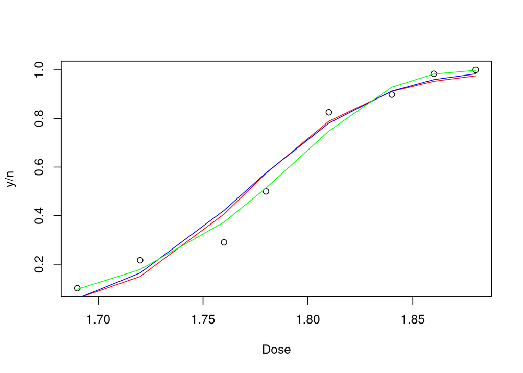

```r
plot(dose.dat$dose,dose.dat$y/dose.dat$n,xlab='Dose',ylab='y/n')
lines(dose.dat$dose,predict(mod.logit, type='response'),col='red')
lines(dose.dat$dose,predict(mod.probit, type='response'),col='blue')
lines(dose.dat$dose,predict(mod.cll, type='response'),col='green')
```

We see that the assymetry allowed by the complementary log-log link function fits the data somewhat better than either the logit or probit models.